# clothing_sales

To demonstrate time series analysis and forecasting, we will use a dataset of clothing sales, available publicly as part of a collection of retail data at kaggle: https://www.kaggle.com/census/advance-retail-sales-time-series-collection.

```python
import matplotlib.pyplot as plt
plt.rcParams['figure.dpi'] = 300
plt.rcParams['figure.figsize'] = (8,5)
import numpy as np
import pandas as pd
import pmdarima as pm
from statsmodels.tsa.stattools import adfuller
from statsmodels.tsa.seasonal import seasonal_decompose
from statsmodels.graphics.tsaplots import plot_acf, plot_pacf

from pandas.plotting import register_matplotlib_converters
register_matplotlib_converters()
```

The usual suspects packages are loaded, including some specific statsmodels functions. Most will likely be familiar. pmdarima is a Python implementation of R's venerable auto.arima.

The last two lines are requested by matplotlib - it'll work without them but give a warning.

Load our data:

```python
data = pd.read_csv("clothing_sales.csv", parse_dates=['date'], index_col="date", dayfirst=True)
data = data.dropna()
data.head()
```

| date | value |
| --- | --- |
| 1992-01-01 | 6938 |
| 1992-02-01 | 7524 |
| 1992-03-01 | 8475 |
| 1992-04-01 | 9401 |
| 1992-05-01 | 9558 |

Let's start with a basic test. The (augmented) Dickey-Fuller test tells us whether our data is stationary. The Null is that it's non-stationary

```python
result = adfuller(data.value)
print(f"ADF Stat = {result[0]}")
print(f"p-value = {result[1]}")
```

```
ADF Stat = -0.12197098575045945
p-value = 0.9472056885348812
```

That's pretty emphatic; our data appears non-stationary.

We can explore the autocorrelattion - the extent to which the value at point x is dependent on the values before x

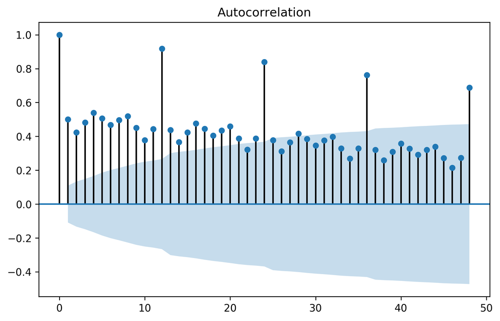

```python
plot_acf(data, lags=48)
plt.show()
```

This shows clearly that the data has a yearly seasonality. The value of $x_{i}$ is shown to be highly correlated with the value of $x_{i-12}$, $x_{i-24}$ etc.

We can also check the partial autocorrelation; the correlation at lag $t$ after correlations for lags less than $t$ have been removed.

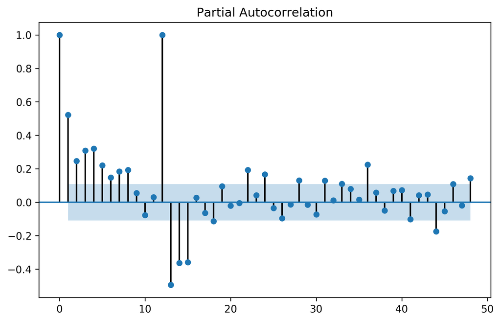

```python
plot_pacf(data, lags=48, alpha=0.05, method="ols")
plt.show()
```

This accords with out intuition: the values at lags below 12 are reasonably well correlated. Lag 12 sees a high correlation, and lags 24, 36 and 48 see reasonable correlation. This suggests that the PACF is still finding evidence of the 12-monthly seasonality rather than a hidden pattern.

There are no obvious additional patterns evident here, so we conclude that the 12-month seasonality of the data is the most significant aspect for any model to capture.

By differencing - displaying the difference between consecutive observations - we can often find a stationary aspect to non-stationary data. This is useful for some calulations and analysis.

In this case, we expect our data to be seasonal, with at least a peak around Xmas time.

We will use both standard and seasonal differencing, to demonstrate how they differ:

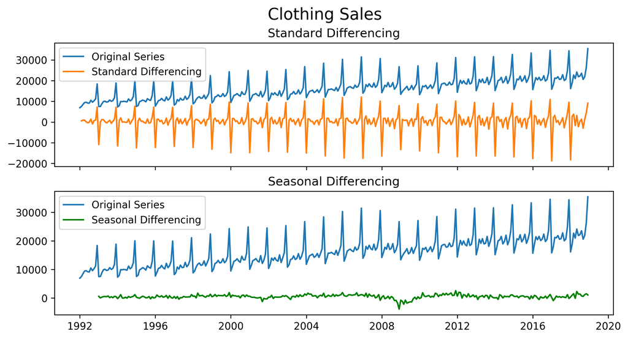

```python
fig, axes = plt.subplots(2, 1, figsize=(10,5), dpi=300, sharex=True)

axes[0].plot(data[:], label="Original Series")
axes[0].plot(data[:].diff(1), label="Standard Differencing")
axes[0].set_title("Standard Differencing")
axes[0].legend(loc="upper left", fontsize=10)

axes[1].plot(data[:], label="Original Series")
axes[1].plot(data[:].diff(12), label="Seasonal Differencing", color="green")
axes[1].set_title("Seasonal Differencing")
plt.legend(loc="upper left", fontsize=10)
plt.suptitle("Clothing Sales", fontsize=16)
plt.show()
```

Clearly normal differencing is inadequate, it completely fails to account for the seasonality. Seasonal differencing doesn't completely model our data, but it gets a lot closer to stationary.

We want to identify the seasonal component and the general trend. For this we use decomposition, specifically the seasonal_decomposition function from statsmodels. In the previous chart, the seasonal differencing shows a stable variance; for this reason we will use an additive model of seasonality in our decomposition. The alternative - if the seasonal difference was itself changing - would be a multiplicative model.

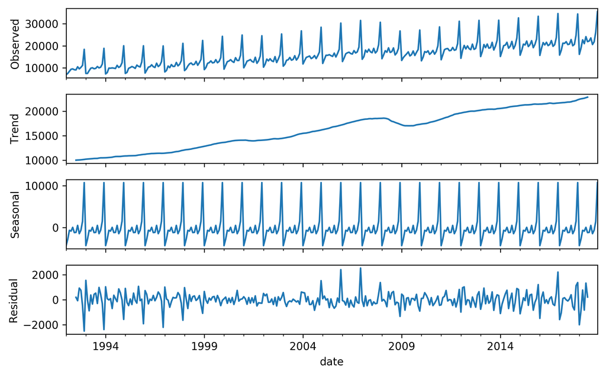

```python
decomp = seasonal_decompose(data, model="additive", freq=12)
decomp.plot()
plt.show()
```

We can observe a stable upward trend, broken only by the financial crisis 0f 2008. A very consistent seasonality accounts for nearly 15k variation in sales, meaning the residuals - the portion of the data unaccounted for by either trend or seasonality - make up only a maximum of about 4k variation.

For forecasting we will create an ARIMA model (SARIMA in fact, due to the seasonality).

We can use the pmdarima package to automate the process of finding the optimal values of **p**, **d** and **q**. This could take a few minutes to run:

```python
smodel = pm.auto_arima(data, start_p=1, start_q=1, test="adf", max_p=3, max_q=3, m=12, start_P=0, seasonal=True,
                       d=None, D=1, trace=True, error_action="ignore", suppress_warnings=True, stepwise=True)

smodel.summary()
```

```
Fit ARIMA: order=(1, 1, 1) seasonal_order=(0, 1, 1, 12); AIC=4858.213, BIC=4876.912, Fit time=2.877 seconds
Fit ARIMA: order=(0, 1, 0) seasonal_order=(0, 1, 0, 12); AIC=4968.391, BIC=4975.870, Fit time=0.060 seconds
Fit ARIMA: order=(1, 1, 0) seasonal_order=(1, 1, 0, 12); AIC=4903.534, BIC=4918.493, Fit time=0.917 seconds
Fit ARIMA: order=(0, 1, 1) seasonal_order=(0, 1, 1, 12); AIC=4855.755, BIC=4870.714, Fit time=3.048 seconds
Fit ARIMA: order=(0, 1, 1) seasonal_order=(1, 1, 1, 12); AIC=4852.210, BIC=4870.909, Fit time=3.929 seconds
Fit ARIMA: order=(0, 1, 1) seasonal_order=(1, 1, 0, 12); AIC=4856.358, BIC=4871.318, Fit time=3.071 seconds
Fit ARIMA: order=(0, 1, 1) seasonal_order=(1, 1, 2, 12); AIC=4852.389, BIC=4874.827, Fit time=13.251 seconds
Fit ARIMA: order=(0, 1, 1) seasonal_order=(0, 1, 0, 12); AIC=4856.709, BIC=4867.929, Fit time=0.753 seconds
Fit ARIMA: order=(0, 1, 1) seasonal_order=(2, 1, 2, 12); AIC=4829.677, BIC=4855.856, Fit time=21.043 seconds
Fit ARIMA: order=(1, 1, 1) seasonal_order=(2, 1, 2, 12); AIC=4832.261, BIC=4862.180, Fit time=19.295 seconds
Fit ARIMA: order=(0, 1, 0) seasonal_order=(2, 1, 2, 12); AIC=4920.888, BIC=4943.326, Fit time=14.769 seconds
Fit ARIMA: order=(0, 1, 2) seasonal_order=(2, 1, 2, 12); AIC=4832.654, BIC=4862.572, Fit time=20.355 seconds
Fit ARIMA: order=(1, 1, 2) seasonal_order=(2, 1, 2, 12); AIC=4831.511, BIC=4865.169, Fit time=21.782 seconds
Fit ARIMA: order=(0, 1, 1) seasonal_order=(2, 1, 1, 12); AIC=4851.612, BIC=4874.051, Fit time=12.482 seconds
Total fit time: 137.667 seconds
```

Statespace Model Results

| Dep. Variable: | y | No. Observations: | 324 |
| --- | --- | --- | --- |
| Model: | SARIMAX(0, 1, 1)x(2, 1, 2, 12) | Log Likelihood | -2407.839 |
| Date: | Mon, 25 Feb 2019 | AIC | 4829.677 |
| Time: | 14:37:46 | BIC | 4855.856 |
| Sample: | 0 | HQIC | 4840.141 |
|  | - 324 |  |  |
| Covariance Type: | opg |  |  |

|  | coef | std err | z | P>\|z\| | [0.025 | 0.975] |
| --- | --- | --- | --- | --- | --- | --- |
| intercept | -12.0809 | 9.927 | -1.217 | 0.224 | -31.538 | 7.376 |
| ma.L1 | -0.5897 | 0.032 | -18.509 | 0.000 | -0.652 | -0.527 |
| ar.S.L12 | 1.0752 | 0.071 | 15.147 | 0.000 | 0.936 | 1.214 |
| ar.S.L24 | -0.9117 | 0.046 | -19.735 | 0.000 | -1.002 | -0.821 |
| ma.S.L12 | -1.1979 | 0.129 | -9.295 | 0.000 | -1.450 | -0.945 |
| ma.S.L24 | 0.9330 | 0.139 | 6.709 | 0.000 | 0.660 | 1.206 |
| sigma2 | 3.189e+05 | 3.7e+04 | 8.631 | 0.000 | 2.46e+05 | 3.91e+05 |

| Ljung-Box (Q): | 62.78 | Jarque-Bera (JB): | 226.99 |
| --- | --- | --- | --- |
| Prob(Q): | 0.01 | Prob(JB): | 0.00 |
| Heteroskedasticity (H): | 1.11 | Skew: | -0.76 |
| Prob(H) (two-sided): | 0.59 | Kurtosis: | 6.90 |

Warnings:  
[1] Covariance matrix calculated using the outer product of gradients (complex-step).

That might look overwhelming, but we don't need to concern ourselves with it. pmdarima has identified the optimal parameters for the model.

We can then use that model to predict sales for the next 36 months (and removing the first 20 years from display, solely for clarity):

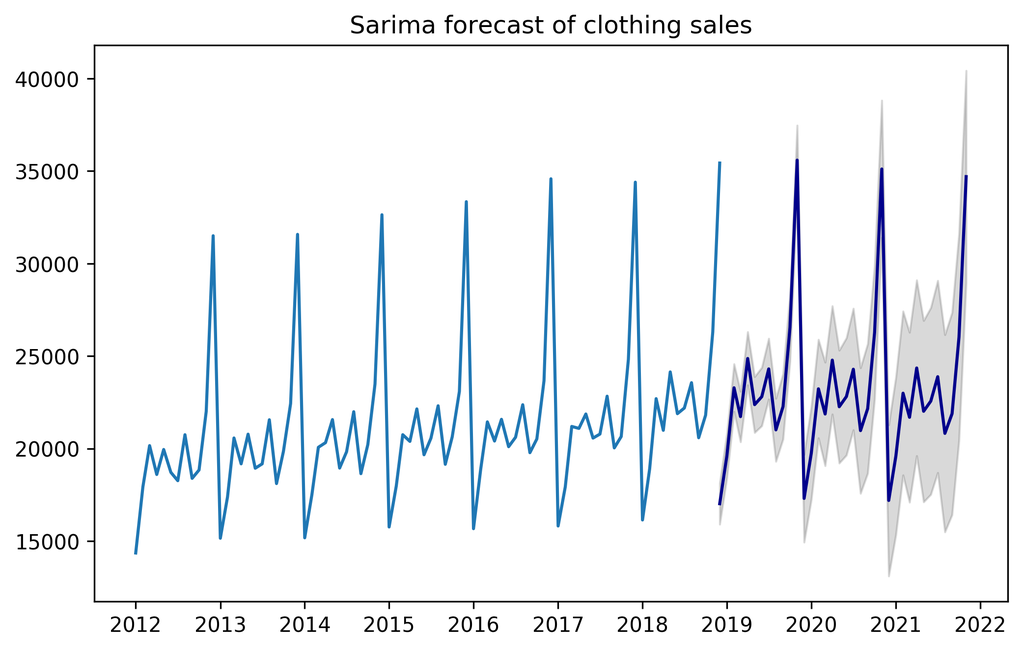

```python
n_periods = 36
fitted, confint = smodel.predict(n_periods=n_periods, return_conf_int=True)
index_of_fc = pd.date_range(data.index[-1], periods=n_periods, freq="MS")

fitted_series = pd.Series(fitted, index=index_of_fc)
lower_series = pd.Series(confint[:,0], index=index_of_fc)
upper_series = pd.Series(confint[:,1], index=index_of_fc)

plt.plot(data[240:])
plt.plot(fitted_series, color="darkblue")
plt.fill_between(lower_series.index, lower_series, upper_series, color="k", alpha=0.15)

plt.title("Sarima forecast of clothing sales")
plt.show()
```

The SARIMA model predicts a slight downturn in sales, but the confidence interval enough that a continued increasing trend would not be surprising. This might be useful for planning long-term stock acquisition, for example.

We can also extract the predictions for additional usage:

```python
fitted_series.head()
```

```
2018-12-01    17020.919331
2019-01-01    19615.889797
2019-02-01    23286.500193
2019-03-01    21728.154267
2019-04-01    24870.692539
Freq: MS, dtype: float64
```